# Streets of Humboldt Bay Area

Max Blasdel

September 29, 2019

The following workflow is inspired by some posts I saw on Reddit visualizing the streets of major cities by their suffixes. I decided to do a version for Humboldt. I came up with my own workflow for creating the maps although other code has been posted.

Data of the streets of Humboldt County was downloaded from the [County Website](https://humboldtgov.org/276/GIS-Data-Download)

## Load Libraries

```r
library(sf) # for spatial manipulation
library(dplyr) # data wrangling
library(ggplot2) # visualization and final graphing
library(mapview) # interactive widget library
```

Find the shapefiles downloaded and unzipped from above link

```r
shapes_path <-
  dir("transport",
      pattern = ".shp$",
      full.names = T)
```

## Load data

```r
roads <-
  read_sf(shapes_path)

head(as.data.frame(roads))
```

```
##   OBJECTID    ID DIR       FUNCTIONAL AB_LANE BA_LANE AB_SPEED BA_SPEED
## 1        1  5788   0      Local Roads       1       1       25       25
## 2        2 20556   0      Local Roads       1       1       25       25
## 3        3 20557   0      Local Roads       1       1       25       25
## 4        4  4436   1 Minor Collectors       2       2       30       30
## 5        5  4830  -1 Minor Collectors       2       2       30       30
## 6        6  4385   0      Local Roads       1       1       25       25
##   LANE_CAPAC FROM_ID TO_ID SG_ID T63_ID T63_CFCC DOT_ROUTE PREFIX
## 1        350    5617  1244  4057  19645      A41         0   <NA>
## 2        350       0     0     0      0     <NA>         0   <NA>
## 3          0       0     0     0      0     <NA>         0   <NA>
## 4        500    4746  5006   616  18770      A41         0   <NA>
## 5        500    5142  5098   566  18729      A41         0   <NA>
## 6        350    4691  4977  6793  20454      A41         0   <NA>
##   STREETNAME STREETTYPE SUFFIX AR1FROM AR1TO AR2FROM AR2TO   CITY
```

[output cut: 34 more lines]

## Prepare Data

Select only the relevant information for plotting

```r
roads <-
  roads %>%
  select(STREETTYPE)
```

Projecting the data into a general lat/long coordinate system.

```r
roads <-
  st_transform(roads, crs = 4326) # WGS 84
```

Select a point to center the map around. I played around with this a bit and chose a point in Arcata Bay.

```r
Euerka <-
  data.frame(y = 40.828731,
            x = -124.116183)

Eureka <-
  st_as_sf(Euerka,
         coords = c("x", "y"),
         crs = 4326) # chose the same coordinate system as above
```

Create a buffer around the chosen point to clip the road data to. The data should really be in a projected coordinate system but this approach still works. The `dist` value here is arc degrees which can be hard to conceptualize. Projecting the data to a UTM coordinate system is probably a better approach.

Check the buffer distance. This was an iterative process made easier by mapview.

```r
st_buffer(Eureka, dist = .08) %>%
  mapview::mapview()
```

[interactive chart not shown]

Create the buffer and crop the roads

```r
buff <-
  st_buffer(Eureka, dist = .08)

roads <-
  st_intersection(roads, buff)
```

There are lots of suffixes that are not well represented in the data. To keep the legend a reasonable size I’m selecting only the top eight suffixes.

```r
top_eight_roads <-
  roads %>%
  as.data.frame() %>%
  dplyr::count(STREETTYPE) %>%
  arrange(desc(n)) %>% # arrange from most to least
  slice(1:8) %>% # take the top eight
  pull(STREETTYPE)
```

Set all of the other suffixes to “Other”

`NA` was one of the top eight values from the above operation. Notice that `NA` is the R value `NA` while every other value is a character (in quotes). Change `NA` the value “None” the character.

```r
roads <-
  roads %>%
    mutate(STREETTYPE = case_when(is.na(STREETTYPE) ~ "None",
                                  STREETTYPE %in% top_eight_roads ~ STREETTYPE,
                                  TRUE ~ "Other"))
roads$STREETTYPE %>%
  unique()
```

```
## [1] "RD"    "CT"    "ST"    "AVE"   "Other" "None"  "LN"    "DR"    "WAY"
```

## Prep data for plotting

Create a vector of colors that is assoicated with each road type and reclassify the characters to factors. This allows the legend to be in the desired order.

```r
road_colors <-  c('RD' = '#FE4D64',
                 'CT' = '#4cb580',
                 'AVE' ='#59c8e5',
                 'ST' = '#fed032',
                 'DR' = '#a7abfe',
                 'LN' = '#fe9ea5',
                 'WAY' = '#2e968c',
                 'NA' = '#919492',
                 'Other' = '#cccccc')

roads$STREETTYPE <- factor(roads$STREETTYPE,
                           levels = c("RD", "CT", "AVE", "ST", "DR", "LN", "WAY", "NA", "Other"))
```

## Plotting

Plot out the finished product. I put the most time into this part and there are probably other ways to acheive the same results with different ggplot functions. I’ve added comments to help identify what does what.

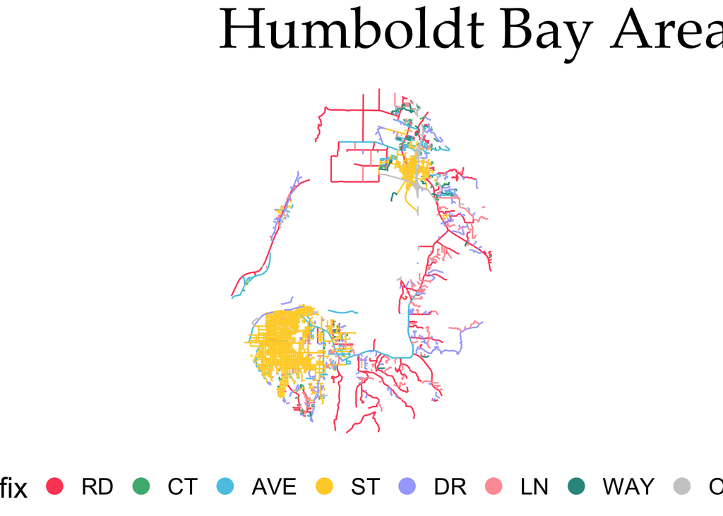

```r
ggplot() +
  geom_sf(data = roads,
          aes(colour = STREETTYPE), # color by column value
          show.legend = "point") + # get legend as circles
  theme_minimal() + # remove default gray background
  coord_sf(datum = NA) + # remove grid lines
  theme(legend.position = "bottom",
        text = element_text(size = 20)) + # set all text large. Play with this number based on desired img size
  guides(color = guide_legend(nrow = 1, # have legend all on one line
                              override.aes = (list(size = 5)))) + # change size of point symbols in legend
  scale_color_manual(name = "Street Suffix", # name of legend
                       values = road_colors) + # colors of legend items
  ggtitle("Humboldt Bay Area") +
  theme(plot.title = element_text(family = "Palatino", # I wanted a serif font because I think they are more elegant
                                  size = 40))
```

## Save output

```r
ggsave("humStreets.png",
       width = 12,
       height = 18,
       units = "in", # specify units of above height and width
       dpi = 400) # dots per inch
```